# Data_Viz_Lab03

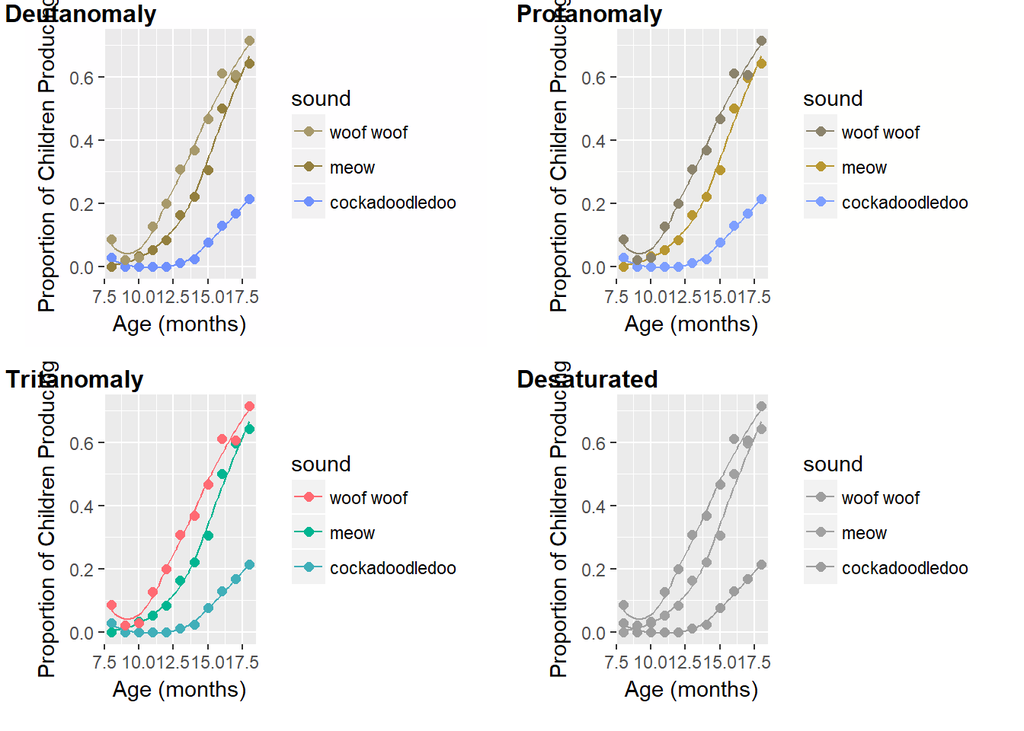

```r
library(colorblindr)
cvd_grid(sound_traj)
```

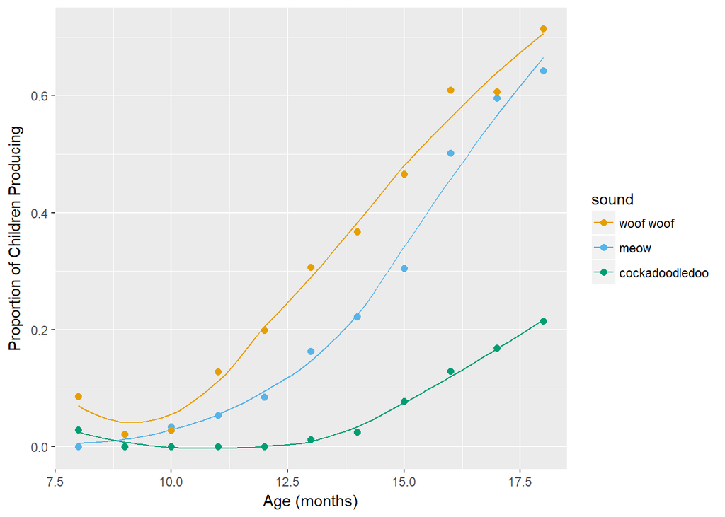

```r
cb_sound_traj <- sound_traj +
  scale_color_OkabeIto()

cb_sound_traj
```

```r
library(ggrepel)
```

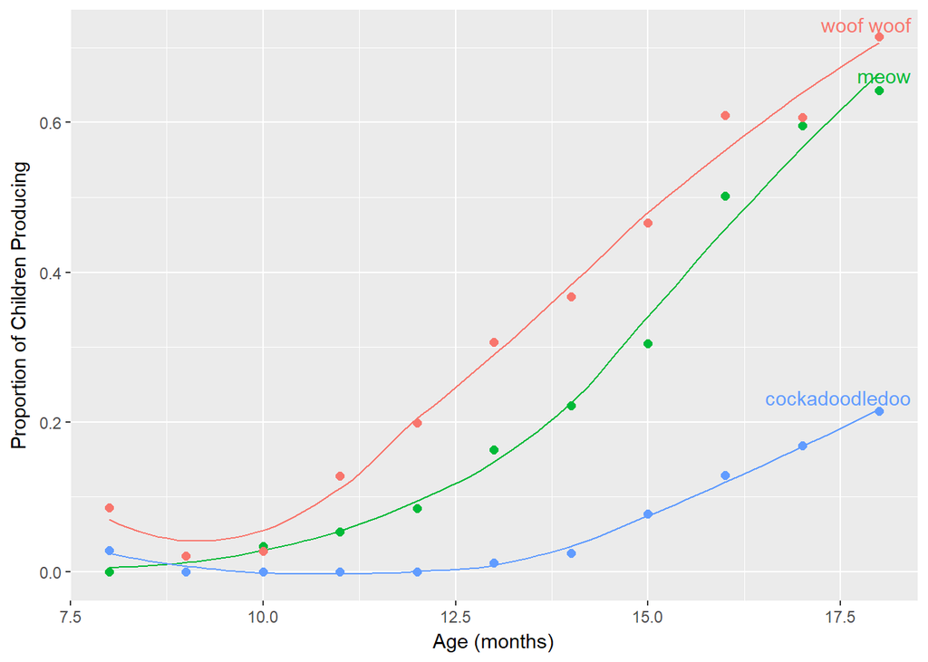

```r
sounds <- sounds %>%
  mutate(label = case_when(
    age == max(age) ~ sound))

ggplot(sounds, aes(x = age,
                   y = prop_produce,
                   color = fct_reorder2(sound, age, prop_produce))) +
  geom_smooth(se = FALSE, lwd = .5) +
  geom_point(size = 2) +
  labs(x = "Age (months)",
       y = "Proportion of Children Producing") +
  geom_text_repel(aes(label = label),
                  nudge_x = 1,
                  direction = "y",
                  na.rm = TRUE) +
  guides(color = FALSE)
```

#### CHALLENGE 10

Subset Data

```r
library(nycflights13)
flights <- nycflights13::weather
flightTemp <- flights %>% filter(year == "2013") %>% select(-(dewp:time_hour)) %>%
  group_by(origin,month) %>% summarise(avg_temp = mean(temp))
```

- Good plot in Color

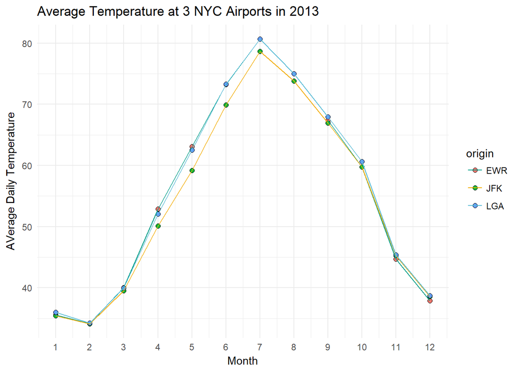

```r
plt <- ggplot(flightTemp, aes(x = month, y = avg_temp, fill = origin))+
  geom_point(size = 2, shape = 21, color = "black")+
  geom_line(aes(color= origin))+
  scale_x_continuous(breaks = seq(1, 12, by = 1))+
  scale_color_manual(values = wes_palette("Darjeeling")[c(2,3,5)])+
  labs( x = "Month", y = "AVerage Daily Temperature")+
  ggtitle("Average Temperature at 3 NYC Airports in 2013")+
  theme_minimal()

plt
```

This plot shows the average daily temperature measured at 3 NYC airports. You can see that JFK has a slightly lower temperature on average than the other airports. The color of the points indicates which airport and the lines show the trend over time.The outline around the points is meant to help distinguish them when they obscure one another. If I had more time/funding I would adjust the scale perhaps to see if the difference can be seen more easily or jitter the points.

- Colorblindness comparison

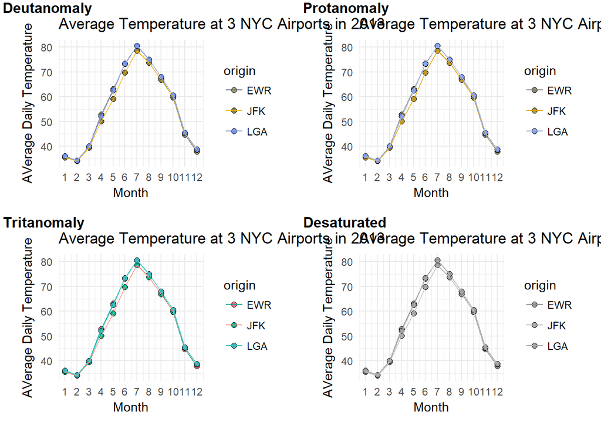

```r
cvd_grid(plt)
```

- Good plot, grayscale

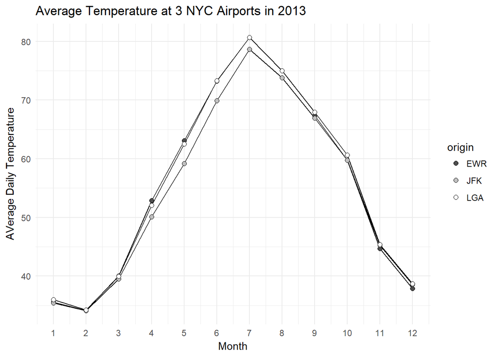

```r
ggplot(flightTemp, aes(x = month, y = avg_temp, fill = origin)) +
  geom_line() +
  geom_point(size = 2, shape = 21) +
  scale_fill_grey(start = 0.3, end = 1)+
  scale_x_continuous(breaks = seq(1, 12, by = 1))+
  labs( x = "Month", y = "AVerage Daily Temperature")+
  ggtitle("Average Temperature at 3 NYC Airports in 2013")+
  theme_minimal()
```

- Heinous Plot

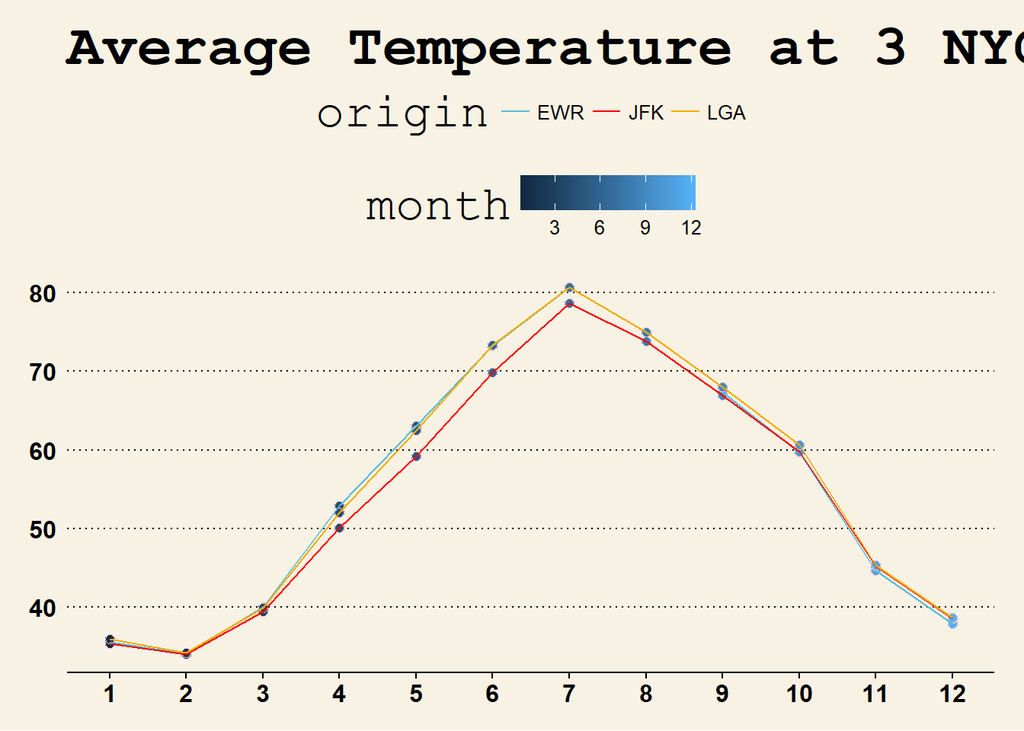

```r
plt <- ggplot(flightTemp, aes(x = month, y = avg_temp, fill = month))+
  geom_point(size = 2, shape = 21, color = "pink")+
  geom_line(aes(color= origin))+
  scale_x_continuous(breaks = seq(1, 12, by = 1))+
  scale_color_manual(values = wes_palette("Darjeeling")[c(5,1,3)])+
  labs( x = "Month", y = "AVerage Daily Temperature")+
  ggtitle("Average Temperature at 3 NYC Airports in 2013")+
  theme_wsj()

plt
```

- This plot is offensive. Color encodes month as well as flight origin. There are useless pink outlines around the points. The background color does not compliment the flight origin colors and seems to emit a smell despite only existing on a computer screen.